# Annotating my genomic variants with snpEFF, snpSift, and ClinVar

# Sequencing my genome

This is the first in a series of notebooks that document my attempt to learn more about myself through sequencing. I’m a bioinformatics scientist with lots of experience tinkering with genomic data sets. When I heard that Nebula Genomics would sequence my whole genome at 30x coverage for $300 AND let me download all of the data (raw `.fastq`, .`.bam`, and `.vcf`), I jumped on the chance to take a look at my own source code. Nebula provided me with a `vcf` file containing 4,785,184 QC passing variants. I want to prioritize which of these millions of variants might deserve a closer look. As a first pass, I annotated these variants to see if any were known to disrupt protein function or play a role in disease.

There are plenty of third-party genetic interpretation websites that can do this kind of thing with your direct-to-consumer genetic test results. I thought it would be more fun to run my own analyses and share them with others that might want to limit the number of companies that have access to their genome. Anyone who has a `vcf` file from Nebula and a little experience with Linux and R should be able to recreate these analyses for themselves. I ran everything below on my little personal laptop (i5, 16G RAM) running Windows 11 with an [Ubuntu Virtualbox install](https://ubuntu.com/tutorials/how-to-run-ubuntu-desktop-on-a-virtual-machine-using-virtualbox#1-overview).

# Publically availible tools and databases

SnpEFF and SnpSift are popular tools for vcf annotation – and for good reason. They generate loads of useful information while remaining user friendly. They are actively maintained as of spring 2022 and have extensive [documentation](https://pcingola.github.io/SnpEff/).

[SnpEff](https://pcingola.github.io/SnpEff/se_introduction/) is a variant annotation and effect prediction tool. It annotates and predicts the effects of genetic variants.

[SnpSift](https://pcingola.github.io/SnpEff/ss_introduction/) is a toolbox that allows you to filter and manipulate annotated files.

Maintained by [Pablo Cingolani](https://pcingola.github.io/SnpEff/about/)

Publications: [SnpEFF](https://pcingola.github.io/SnpEff/adds/SnpEff_paper.pdf), [SnpSift](https://pcingola.github.io/SnpEff/adds/SnpSift_paper.pdf)

[GATK](https://gatk.broadinstitute.org/hc/en-us) is incredible software with many tools for genomic analyses. I only use it here to convert the `vcf` into something easier to read.

[ClinVar](https://www.ncbi.nlm.nih.gov/clinvar/) is a freely accessible, public archive of reports of the relationships among human variations and phenotypes, with supporting evidence. I use this database to help prioritize which of the millions of variants in my genome deserve a closer look.

SNPedia is a wiki investigating human genetics that shares information about the effects of variations in DNA, citing peer-reviewed scientific publications. I use this resource to read quick facts about specific genetic variants and find associated publications. Unfortunately, it doesn’t seem to be very actively maintained since it was [purchased by myHeritage](https://blog.myheritage.com/2019/09/myheritage-acquires-promethease-and-snpedia/) along with Promethease.

# Load R libraries

```r
start_time <- Sys.time()

suppressPackageStartupMessages(library(tidyverse))
#library(vroom)
library(rsnps)
library(gt)
#library(beepr)

# Wong, B. Points of view: Color blindness. Nat Methods (2011).
bla <- '#000000'
blu <- '#0072b2'
grb <- '#56b4e9'
lir <- '#cc79a7'
gre <- '#009e73'
red <- '#d55e00'
org <- '#e69f00'
yel <- '#f0e442'
gry <- '#BBBBBB'
```

# Annotating my `vcf` with SnpEFF

## Setup

Downloading and installing SnpEFF is quick and easy.

```bash
wget https://snpeff.blob.core.windows.net/versions/snpEff_latest_core.zip
unzip snpEff_latest_core.zip
```

You must specify which genome was used during alignment to call varaiants in the vcf. Nebula currently aligns to hg38.

```bash
java -jar /media/sf_dna/apps/snpEff/snpEff.jar download -v hg38
```

This creates a new `vcf` with annotations for variants in the Nebula `vcf`.

```bash
java -Xmx8g -jar /media/sf_dna/apps/snpEff/snpEff.jar hg38 /media/sf_dna/nebula/vcf/nebula.vcf > myVariants.ann.vcf
```

GATK is also quick and easy to install.

```bash
sudo apt install default-jre
wget https://github.com/broadinstitute/gatk/releases/download/4.2.5.0/gatk-4.2.5.0.zip
unzip gatk-4.2.5.0.zip
# set alias in bash profile
# alias gatk='/media/sf_dna/apps/gatk-4.2.5.0/gatk'
```

I convert the `vcf` annotated by SnpEFF to a tab delimited text file with GATK. This makes the data a little easier to read and can be fed into R as a data frame. I also replace my Nebula ID with ‘myVariants’ to make downstream scripts more generic.

```bash
gatk VariantsToTable -V myVariants.ann.vcf -F CHROM -F POS -F TYPE -F ID -F ANN -F LOF -F NMD -GF AD -GF DP -GF GQ -GF GT -O myVariants.ann.txt

nebulaID="##########"
sed -i "1s/$nebulaID/myVariants/g" myVariants.ann.txt
```

## Possible variant annotations

The annotated `vcf` output by SnpEFF has lots of information about how a variant influences molecular phenotypes (not necessarily disease phenotypes, which are explored below with SnpSift and Clinvar). Molecular effects are described by a sequence ontology term and associated with an estimate the magnitude of the functional impact.

```r
annotated_vcf_table <- "C:/Users/jmcgirr/dna/nebula/vcf/myVariants.ann.txt"

ann <- read_table(annotated_vcf_table, guess_max = 1000000)

# table based on SnpEFF documentation
ann_types <- data.frame(impact = c("HIGH","HIGH","HIGH","HIGH","HIGH","HIGH","HIGH","HIGH","HIGH","HIGH","MODERATE","MODERATE","MODERATE","MODERATE","MODERATE","MODERATE","MODERATE","MODERATE","MODERATE","MODERATE","MODERATE","LOW","LOW","LOW","LOW","LOW","LOW","MODIFIER","MODIFIER","MODIFIER","MODIFIER","MODIFIER","MODIFIER","MODIFIER","MODIFIER","MODIFIER","MODIFIER","MODIFIER","MODIFIER","MODIFIER","MODIFIER","MODIFIER","MODIFIER","MODIFIER","MODIFIER","MODIFIER","MODIFIER","MODIFIER","MODIFIER","MODIFIER","MODIFIER","MODIFIER"),
                     ontology_term = c("chromosome_number_variation","exon_loss_variant","frameshift_variant","rare_amino_acid_variant","splice_acceptor_variant","splice_donor_variant","start_lost","stop_gained","stop_lost","transcript_ablation","3_prime_UTR_truncation&exon_loss","5_prime_UTR_truncation&exon_loss_variant","coding_sequence_variant-moderate","conservative_inframe_deletion","conservative_inframe_insertion","disruptive_inframe_deletion","disruptive_inframe_insertion","missense_variant","regulatory_region_ablation","splice_region_variant-moderate","TFBS_ablation","5_prime_UTR_premature_start_codon_gain_variant","initiator_codon_variant","splice_region_variant-low","start_retained","stop_retained_variant","synonymous_variant","3_prime_UTR_variant","5_prime_UTR_variant","coding_sequence_variant-modifier","conserved_intergenic_variant","conserved_intron_variant","downstream_gene_variant","exon_variant","feature_elongation","feature_truncation","gene_variant","intergenic_region","intragenic_variant","intron_variant","mature_miRNA_variant","miRNA","NMD_transcript_variant","non_coding_transcript_exon_variant","non_coding_transcript_variant","regulatory_region_amplification","regulatory_region_variant","TF_binding_site_variant","TFBS_amplification","transcript_amplification","transcript_variant","upstream_gene_variant"))

ann_types |> gt() |> tab_header(title = "Putative impact for sequence ontology terms output by SnpEFF")
```

Putative impact for sequence ontology terms output by SnpEFF

| impact | ontology_term |
| --- | --- |
| HIGH | chromosome_number_variation |
| HIGH | exon_loss_variant |
| HIGH | frameshift_variant |
| HIGH | rare_amino_acid_variant |
| HIGH | splice_acceptor_variant |
| HIGH | splice_donor_variant |
| HIGH | start_lost |
| HIGH | stop_gained |
| HIGH | stop_lost |
| HIGH | transcript_ablation |
| MODERATE | 3_prime_UTR_truncation&exon_loss |
| MODERATE | 5_prime_UTR_truncation&exon_loss_variant |
| MODERATE | coding_sequence_variant-moderate |
| MODERATE | conservative_inframe_deletion |
| MODERATE | conservative_inframe_insertion |
| MODERATE | disruptive_inframe_deletion |
| MODERATE | disruptive_inframe_insertion |
| MODERATE | missense_variant |
| MODERATE | regulatory_region_ablation |
| MODERATE | splice_region_variant-moderate |
| MODERATE | TFBS_ablation |
| LOW | 5_prime_UTR_premature_start_codon_gain_variant |
| LOW | initiator_codon_variant |
| LOW | splice_region_variant-low |
| LOW | start_retained |
| LOW | stop_retained_variant |
| LOW | synonymous_variant |
| MODIFIER | 3_prime_UTR_variant |
| MODIFIER | 5_prime_UTR_variant |
| MODIFIER | coding_sequence_variant-modifier |
| MODIFIER | conserved_intergenic_variant |
| MODIFIER | conserved_intron_variant |
| MODIFIER | downstream_gene_variant |
| MODIFIER | exon_variant |
| MODIFIER | feature_elongation |
| MODIFIER | feature_truncation |
| MODIFIER | gene_variant |
| MODIFIER | intergenic_region |
| MODIFIER | intragenic_variant |
| MODIFIER | intron_variant |
| MODIFIER | mature_miRNA_variant |
| MODIFIER | miRNA |
| MODIFIER | NMD_transcript_variant |
| MODIFIER | non_coding_transcript_exon_variant |
| MODIFIER | non_coding_transcript_variant |
| MODIFIER | regulatory_region_amplification |
| MODIFIER | regulatory_region_variant |
| MODIFIER | TF_binding_site_variant |
| MODIFIER | TFBS_amplification |
| MODIFIER | transcript_amplification |
| MODIFIER | transcript_variant |
| MODIFIER | upstream_gene_variant |

## My variant annotations

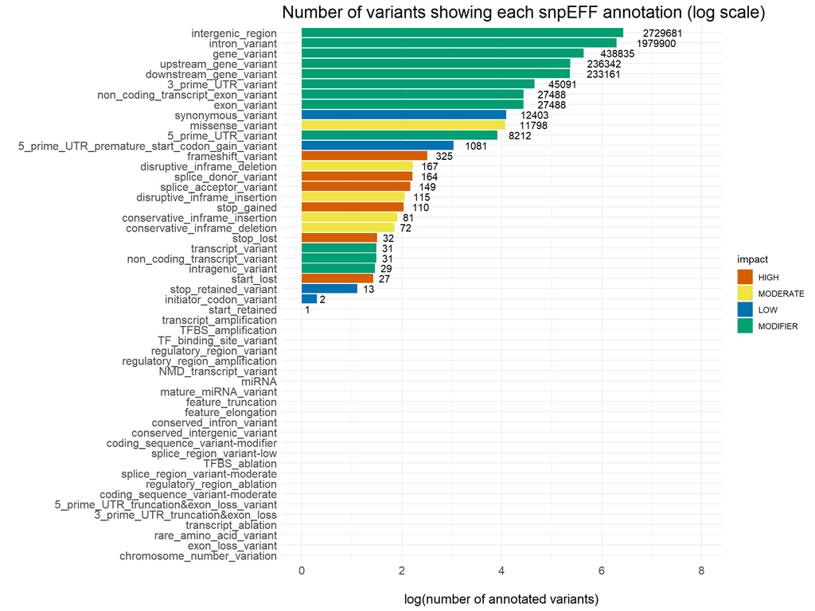

```r
# # count the number of variants annotated for each ontology
# n_variants <- c()
# for(ot in ann_types$ontology_term){
#   n_variants <- c(n_variants,(filter(ann, grepl(ot, ANN)) |> nrow()))
#   #print(ot)
# }



# count the number of variants annotated for each ontology
n_variants <- vector("double", length(ann_types$ontology_term))

for(i in seq_along(ann_types$ontology_term)){

  n_variants[[i]] <- filter(ann, str_detect(ANN, fixed(ann_types$ontology_term[[i]]))) |> nrow()

}


ann_types$n_variants <- n_variants
ann_types <- arrange(ann_types, n_variants)

ann_types$ontology_term <- factor(ann_types$ontology_term, levels = ann_types$ontology_term)
ann_types$impact <- factor(ann_types$impact, levels = c("HIGH","MODERATE","LOW","MODIFIER"))
ann_types$log_n_variants <- log10(ann_types$n_variants)

p1 <- ann_types|>
   ggplot(aes(ontology_term, log_n_variants, fill = impact)) +
   geom_col() +
   coord_flip() +
   theme_minimal() +
   theme(axis.title.x=element_text(size=14),
    axis.title.y=element_text(size=12),
    axis.title=element_text(size=14),
    axis.text=element_text(size=12),
    plot.title=element_text(size=18))+
   ylab("\nlog(number of annotated variants)")+ xlab("")+ ylim(0,8)+
   ggtitle("Number of variants showing each snpEFF annotation (log scale)")+
   geom_text(aes(label=n_variants), position=position_stack(), hjust=-0.5)+
   scale_fill_manual(values = c(red,yel,blu,gre))
print(p1)
```

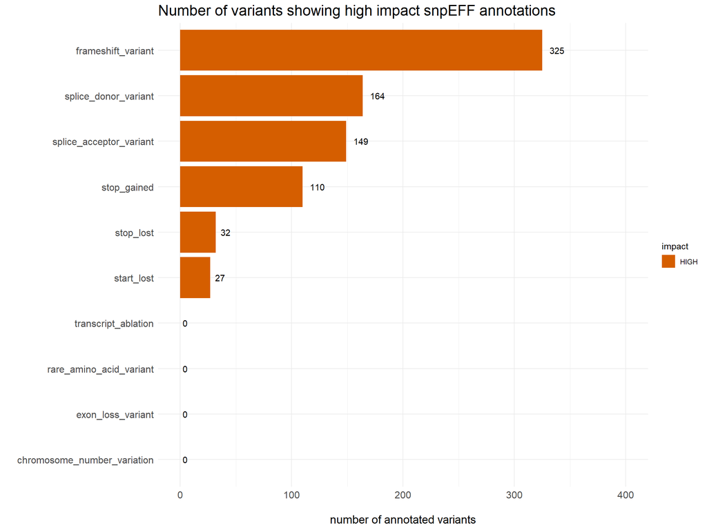

```r
p1 <- ann_types|> filter(impact %in% c("HIGH"), ontology_term != "missense_variant") |>
   ggplot(aes(ontology_term, n_variants, fill = impact)) +
   geom_col() +
   coord_flip() +
   theme_minimal() +
   theme(axis.title.x=element_text(size=14),
    axis.title.y=element_text(size=14),
    axis.title=element_text(size=18),
    axis.text=element_text(size=12),
    plot.title=element_text(size=18))+
   ylab("\nnumber of annotated variants")+ xlab("")+ylim(0,400)+
   ggtitle("Number of variants showing high impact snpEFF annotations")+
   geom_text(aes(label=n_variants), position=position_stack(), hjust=-0.5)+
   scale_fill_manual(values = c(red,yel,blu,gre))
print(p1)
```

## Investigate high impact variants on SNPedia

Tables show my genotype (on the plus strand) along with genotype quality and allele depth. Links point to SNPedia entries for variants annotated as high impact. It seems only a few entries exist for each annotation type.

```r
# get table with rsids for an ontology term
annotations.for.ontology.term <- function(ontology_term){

  ot_table <- filter(ann, str_detect(ANN, fixed(ontology_term)))
  anns <- ot_table$ANN

  ot_anns <- c()
  ot_alleles <- c()
  for(ann_string in anns){
    ot_anns <- c(ot_anns,paste0(paste(strsplit(grep(ontology_term, strsplit(ann_string, ",")[[1]], value = TRUE)[1], "\\|")[[1]][c(1,2,3,4,7)], collapse = "|"),"|"))
  }

  ot_table$ANN <- ot_anns
  ot_table <- separate(ot_table,ANN, c("allele","annotation","impact","gene_name","feature_id"), sep = "\\|", extra = "drop")
  return(ot_table)
}

# search for SNPedia annotations for rsids output by annotations.for.ontology.term()
get.snpedia.urls <- function(ot_table){

  snpedia_urls <- c()
  myGTs  <- myADs <- myGQs <- c()
  ot_table <- filter(ot_table, grepl("rs",ID))

  for(rsid in ot_table$ID){
  snpedia_table <- annotations(snp = rsid, output = 'snpedia')
    if(nrow(snpedia_table)>0){
      snpedia_urls <- c(snpedia_urls,gsub("\\s*\\([^\\)]+\\)","",snpedia_table$url[1]))
      myGTs <- c(myGTs, filter(ot_table, ID == rsid) |> pull(myVariants.GT))
      myADs <- c(myADs, filter(ot_table, ID == rsid) |> pull(myVariants.AD))
      myGQs <- c(myGQs, filter(ot_table, ID == rsid) |> pull(myVariants.GQ))

    }
  }

  return(data.frame(SNPedia_urls = snpedia_urls, Genotype_PlusOrientation = myGTs,
                    Allele_Depth = myADs, Genotype_Quality = myGQs))

}

make.hyperlink <-  function(myurl,mytext=myurl) {
  paste('<a href="',myurl,'">',mytext,'</a>')
}

for(i_ontology_term in (filter(ann_types, impact == "HIGH", n_variants > 0) |> pull(ontology_term))){
print(get.snpedia.urls(annotations.for.ontology.term(i_ontology_term)) |>
        gt() |>
        tab_header(title = paste0("SNPedia entries for variants annotated as ", i_ontology_term)) |>
        fmt (columns = 'SNPedia_urls',fns = make.hyperlink))
}
```

SNPedia entries for variants annotated as start_lost

| SNPedia_urls | Genotype_PlusOrientation | Allele_Depth | Genotype_Quality |
| --- | --- | --- | --- |
| http://www.snpedia.com/index.php/Rs3764880 | G/G | 0,116 | 99 |

SNPedia entries for variants annotated as stop_lost

| SNPedia_urls | Genotype_PlusOrientation | Allele_Depth | Genotype_Quality |
| --- | --- | --- | --- |
| http://www.snpedia.com/index.php/Rs241448 | A/G | 36,35 | 99 |

SNPedia entries for variants annotated as stop_gained

| SNPedia_urls | Genotype_PlusOrientation | Allele_Depth | Genotype_Quality |
| --- | --- | --- | --- |
| http://www.snpedia.com/index.php/Rs17602729 | G/A | 85,100 | 99 |
| http://www.snpedia.com/index.php/Rs6661174 | T/T | 0,126 | 99 |
| http://www.snpedia.com/index.php/Rs1815739 | T/T | 0,113 | 99 |
| http://www.snpedia.com/index.php/Rs601338 | G/A | 59,63 | 99 |

SNPedia entries for variants annotated as splice_acceptor_variant

| SNPedia_urls | Genotype_PlusOrientation | Allele_Depth | Genotype_Quality |
| --- | --- | --- | --- |
| http://www.snpedia.com/index.php/Rs776746 | C/C | 0,117 | 99 |
| http://www.snpedia.com/index.php/Rs3892097 | C/T | 134,68 | 99 |

SNPedia entries for variants annotated as splice_donor_variant

| SNPedia_urls | Genotype_PlusOrientation | Allele_Depth | Genotype_Quality |
| --- | --- | --- | --- |
| http://www.snpedia.com/index.php/Rs2004640 | G/G | 0,116 | 99 |

SNPedia entries for variants annotated as frameshift_variant

| SNPedia_urls | Genotype_PlusOrientation | Allele_Depth | Genotype_Quality |
| --- | --- | --- | --- |
| http://www.snpedia.com/index.php/Rs8176719 | TC/TC | 0,114 | 99 |
| http://www.snpedia.com/index.php/Rs2066847 | G/GC | 87,87 | 99 |

# Annotating my `vcf` with SnpSift and Clinvar

SnpSift is automatically installed along with SnpEFF.

SnpSift takes annotations from one `vcf` and transfers them to matching variants in another `vcf`.

I annotate my Nebula `vcf` using a `vcf` curated by Clinvar. The Clinvar `vcf` reports the [clinical significance](https://www.ncbi.nlm.nih.gov/clinvar/docs/clinsig/) of each variant based on supporting literature. I use this to prioritize possible variants of concern (annotated as pathogenic).

Download the Clinvar `vcf`.

```bash
wget https://ftp.ncbi.nlm.nih.gov/pub/clinvar/vcf_GRCh38/clinvar.vcf.gz
```

Annotate my `vcf` with Clinvar `vcf` and convert to tab delimited table with GATK.

```bash
java -jar /media/sf_dna/apps/snpEff/SnpSift.jar annotate /media/sf_dna/clinvar/clinvar.vcf.gz /media/sf_dna/nebula/vcf/NG1T6RKMCV.vcf > myVariants.clinvar.vcf

gatk VariantsToTable -V /media/sf_dna/nebula/vcf/myVariants.dbNSFP.vcf -F CHROM -F POS -F TYPE -F ID -F ALLELEID -F CLNDN -F CLNSIG -F CLNSIGCONF -F CLNSIGINCL -F CLNVC -F GENEINFO -GF AD -GF GQ -GF GT -O myVariants.clinvar.txt

sed -i '1s/NG1T6RKMCV/myVariants/g' myVariants.clinvar.txt
```

## Identify possible pathogenic variants

```r
annotated_vcf_table <- "C:/Users/jmcgirr/dna/nebula/vcf/myVariants.clinvar.txt"

ann <- read_table(annotated_vcf_table, guess_max = 1000000) |>
      filter(!is.na(ALLELEID))
patho <- filter(ann, str_detect(CLNSIG, fixed("Pathogenic")) | str_detect(CLNSIG, fixed("Likely_pathogenic"))) |> separate("ID", c("ID","unknown"), sep = ";")
#unique(patho$CLNSIG)
#nrow(patho)
as.data.frame(patho) |> gt()
```

| CHROM | POS | TYPE | ID | unknown | ALLELEID | CLNDN | CLNSIG | CLNSIGCONF | CLNSIGINCL | CLNVC | GENEINFO | myVariants.AD | myVariants.DP | myVariants.GQ | myVariants.GT |
| --- | --- | --- | --- | --- | --- | --- | --- | --- | --- | --- | --- | --- | --- | --- | --- |
| chr1 | 161223893 | SNP | rs5082 | 17936 | 32975 | Familial_hypercholesterolemia_1 | Pathogenic | NA | NA | single_nucleotide_variant | APOA2:336 | 0,90 | 90 | 99 | A/A |
| chr3 | 124055231 | SNP | rs9289231 | 5458 | 20497 | Coronary_heart_disease_5 | Pathogenic | NA | NA | single_nucleotide_variant | KALRN:8997 | 107,87 | 195 | 99 | T/G |
| chr8 | 66178947 | SNP | rs12721510 | 38800 | 47403 | Autosomal_dominant_nocturnal_frontal_lobe_epilepsy | Pathogenic | NA | NA | single_nucleotide_variant | CRH:1392 | 66,75 | 141 | 99 | G/T |
| chr8 | 91071260 | SNP | rs1395982289 | 1216417 | 1206397 | not_provided | Likely_pathogenic | NA | NA | single_nucleotide_variant | OTUD6B:51633 | 87,100 | 190 | 99 | C/T |
| chr11 | 5249833 | SNP | rs368698783 | 1048099 | 1036027 | Hereditary_persistence_of_fetal_hemoglobin | Pathogenic | NA | NA | single_nucleotide_variant | HBG1:3047\|LOC106099064:106099064 | 8,6 | 14 | 99 | C/T |
| chr16 | 27344882 | SNP | rs1805010 | 14666 | 29705 | Acquired_immunodeficiency_syndrome,_slow_progression_to\|Atopy,_resistance_to | Pathogenic\|_protective | NA | NA | single_nucleotide_variant | IL4R:3566 | 53,40 | 95 | 99 | A/G |
| chr17 | 34252769 | SNP | rs1024611 | 14207 | 29246 | Spina_bifida,_susceptibility_to\|Mycobacterium_tuberculosis,_susceptibility_to\|Coronary_artery_disease,_modifier_of\|Coronary_artery_disease,_development_of,_in_hiv | Pathogenic\|_risk_factor | NA | NA | single_nucleotide_variant | CCL2:6347 | 92,92 | 185 | 99 | A/G |

## Investigate pathogenic variants on SNPedia

```r
print(get.snpedia.urls(patho) |>
      gt() |>
      tab_header(title = "SNPedia entries for variants annotated as pathoginic or likely pathogenic") |>
      fmt (columns = 'SNPedia_urls',fns = make.hyperlink))
```

SNPedia entries for variants annotated as pathoginic or likely pathogenic

| SNPedia_urls | Genotype_PlusOrientation | Allele_Depth | Genotype_Quality |
| --- | --- | --- | --- |
| http://www.snpedia.com/index.php/Rs5082 | A/A | 0,90 | 99 |
| http://www.snpedia.com/index.php/Rs9289231 | T/G | 107,87 | 99 |
| http://www.snpedia.com/index.php/Rs12721510 | G/T | 66,75 | 99 |
| http://www.snpedia.com/index.php/Rs1805010 | A/G | 53,40 | 99 |
| http://www.snpedia.com/index.php/Rs1024611 | A/G | 92,92 | 99 |

# Notes

## Git repo

https://github.com/joemcgirr/joe_genome/tree/main/snpEFF

### R run time and session info

```r
end_time <- Sys.time()
print(end_time - start_time)
```

```
## Time difference of 9.307065 mins
```